# IODS course project

Heli Helskyaho

# Introduction to Open Data Science - Course Project

# About the project

I am looking forward to learn a lot about machine learning and R during this course. My GitHUb is https://github.com/hhelskya/IODS-project

```r
# This is a so-called "R chunk" where you can write R code.

date()
```

```
## [1] "Thu Nov 12 10:33:11 2020"
```

Cannot wait to learn more.

# Regression and model validation

*Describe the work this week and summarize your learning.*

- Describe your work and results clearly.
- Assume the reader has an introductory course level understanding of writing and reading R code as well as statistical methods.
- Assume the reader has no previous knowledge of your data or the more advanced methods you are using.

```r
date()
```

```
## [1] "Thu Nov 12 10:33:11 2020"
```

```r
ds <- read.csv("C:/Users/Heli/Heli/HY/Introduction to Open Data Science/Projects/IODS-project/data\\learning2014.csv", header=TRUE)
ds$Points
```

```
##   [1] 25 12 24 10 22 21 21 31 24 26 31 31 23 25 21 31 20 22  9 24 28 30 24  9 26
##  [26] 32 32 33 29 30 19 23 19 12 10 11 20 26 31 20 23 12 24 17 29 23 28 31 23 25
##  [51] 18 19 22 25 21  9 28 25 29 33 33 25 18 22 17 25 28 22 26 11 29 22 21 28 33
##  [76] 16 31 22 31 23 26 12 26 31 19 30 12 17 18 19 21 24 28 17 18 17 23 26 28 31
## [101] 27 25 23 21 27 28 23 21 25 11 19 24 28 21 24 24 20 19 30 22 16 16 19 30 23
## [126] 19 18 28 21 19 27 24 21 20 28 12 21 28 31 18 25 19 21 16  7 21 17 22 18 25
## [151] 24 23 23 26 12 32 22 20 21 23 20 28 31 18 30 19
```

```r
dim(ds)
```

```
## [1] 166   7
```

```r
str(ds)
```

```
## 'data.frame':    166 obs. of  7 variables:
##  $ gender  : chr  "F" "M" "F" "M" ...
##  $ Age     : int  53 55 49 53 49 38 50 37 37 42 ...
##  $ attitude: num  1.5 1.67 1.5 2.17 1.83 ...
##  $ deep    : num  3.58 2.92 3.5 3.5 3.67 ...
##  $ stra    : num  3.38 2.75 3.62 3.12 3.62 ...
##  $ surf    : num  2.58 3.17 2.25 2.25 2.83 ...
##  $ Points  : int  25 12 24 10 22 21 21 31 24 26 ...
```

```r
summary(ds)
```

```
##     gender               Age           attitude          deep
##  Length:166         Min.   :17.00   Min.   :1.000   Min.   :1.583
##  Class :character   1st Qu.:21.00   1st Qu.:1.500   1st Qu.:3.333
##  Mode  :character   Median :22.00   Median :1.667   Median :3.667
##                     Mean   :25.51   Mean   :1.883   Mean   :3.680
##                     3rd Qu.:27.00   3rd Qu.:2.000   3rd Qu.:4.083
##                     Max.   :55.00   Max.   :4.667   Max.   :4.917
##       stra            surf           Points
##  Min.   :1.250   Min.   :1.583   Min.   : 7.00
##  1st Qu.:2.625   1st Qu.:2.417   1st Qu.:19.00
##  Median :3.188   Median :2.833   Median :23.00
##  Mean   :3.121   Mean   :2.787   Mean   :22.72
##  3rd Qu.:3.625   3rd Qu.:3.167   3rd Qu.:27.75
##  Max.   :5.000   Max.   :4.333   Max.   :33.00
```

The dataset contains 166 rows and 7 columns. It includes the gender (F/M), the age, the points and some combination variables built using mean. These variables and the original variables they are combined are:

attitude: Aa, Ab, Ac, Ad, Ae, Af deep: D03+D11+D19+D27, D07+D14+D22+D30, D06+D15+D23+D31 surf: SU02+SU10+SU18+SU26, SU05+SU13+SU21+SU29, SU08+SU16+SU24+SU32 stra: ST01+ST09+ST17+ST25, ST04+ST12+ST20+ST28

Gender is of type chr, age and points are of type int and the rest of the variables are of type num as shown here: ‘data.frame’: 166 obs. of 7 variables: $ X.gender. : chr “"F"” “"M"” “"F"” “"M"” … $ X.Age. : int 53 55 49 53 49 38 50 37 37 42 … $ X.attitude.: num 1.5 1.67 1.5 2.17 1.83 … $ X.deep. : num 3.58 2.92 3.5 3.5 3.67 … $ X.stra. : num 3.38 2.75 3.62 3.12 3.62 … $ X.surf. : num 2.58 3.17 2.25 2.25 2.83 … $ X.Points. : int 25 12 24 10 22 21 21 31 24 26 …

The minimum age in the dataset is 17, maximum 55. Values for attitude are between 1.000-4.667, for deep between 1.583-4.917, stra 1.250-5.000, and surf 1.583-4.333. The minimum points are 7.00 and the maximum points are 33.00. The table below shows also the 1st quadrant, median, mean, and 3. quadrant for each variable.

X.gender. X.Age. X.attitude. X.deep. X.stra. X.surf.  
Length:166 Min. :17.00 Min. :1.000 Min. :1.583 Min. :1.250 Min. :1.583  
Class :character 1st Qu.:21.00 1st Qu.:1.500 1st Qu.:3.333 1st Qu.:2.625 1st Qu.:2.417  
Mode :character Median :22.00 Median :1.667 Median :3.667 Median :3.188 Median :2.833  
Mean :25.51 Mean :1.883 Mean :3.680 Mean :3.121 Mean :2.787  
3rd Qu.:27.00 3rd Qu.:2.000 3rd Qu.:4.083 3rd Qu.:3.625 3rd Qu.:3.167  
Max. :55.00 Max. :4.667 Max. :4.917 Max. :5.000 Max. :4.333  
X.Points.  
Min. : 7.00  
1st Qu.:19.00  
Median :23.00  
Mean :22.72  
3rd Qu.:27.75  
Max. :33.00

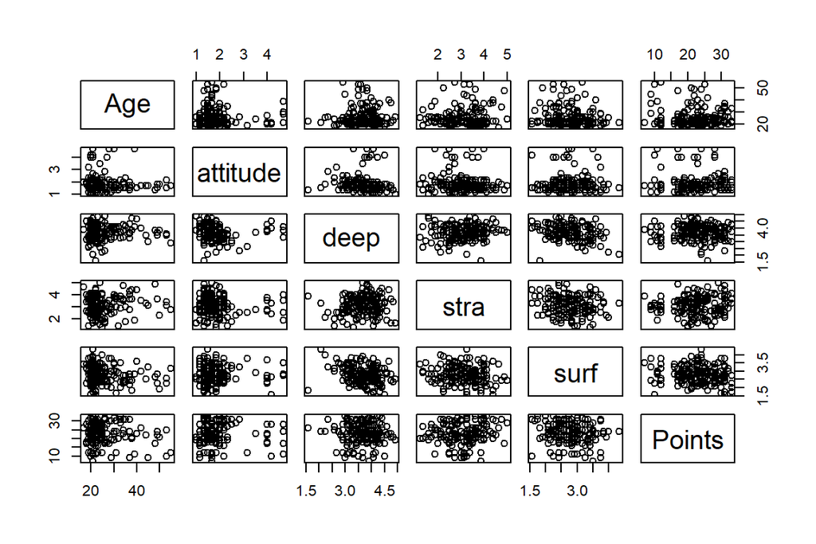

```r
pairs(ds[-1])
```

The scatter plot above describes the relationships between the variables. We have removed gender from the scatter plot.

```r
library(GGally)
```

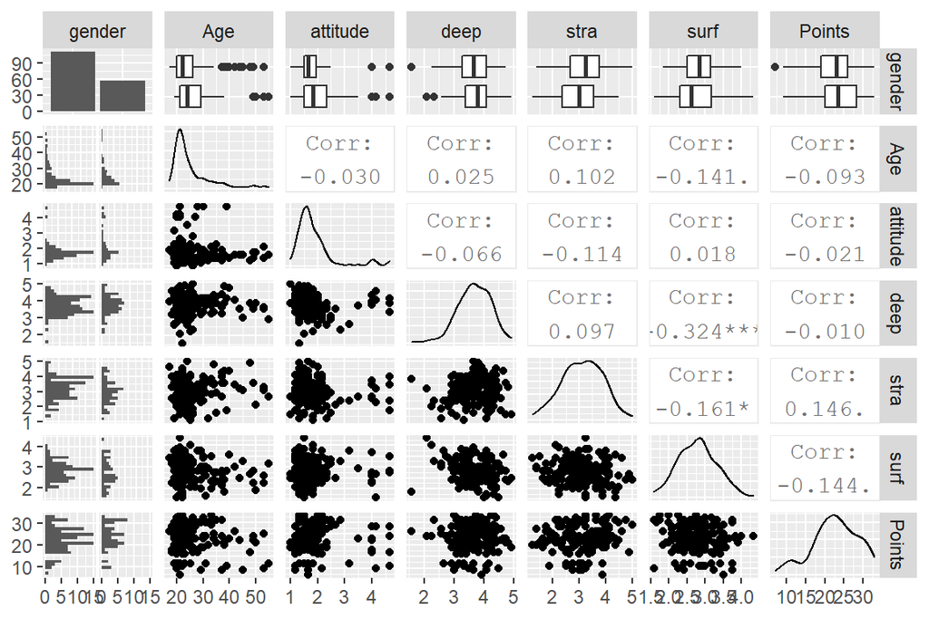

```r
library(ggplot2)
p <- ggpairs(ds, mapping = aes(), lower = list(combo = wrap("facethist", bins = 20)))
p
```

Above you can see a more advanced plot describing for instance the correlation of different variables to each others and the distribuiton of each variable.

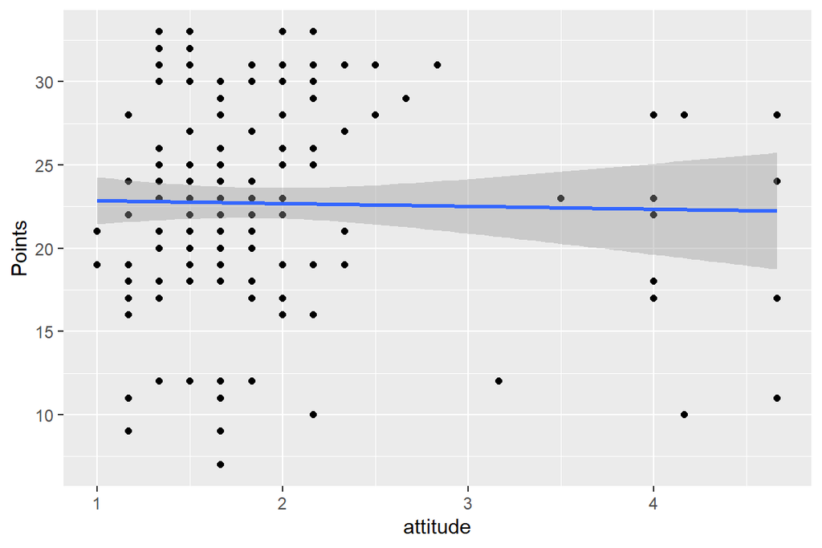

```r
# a scatter plot of points versus attitude
library(ggplot2)
# colnames(learning2014)[7] <- "points"

qplot(attitude, Points, data = ds) + geom_smooth(method = "lm")
```

```r
my_model <- lm(Points  ~ attitude + deep + Age, data = ds )
summary(my_model)
```

```
##
## Call:
## lm(formula = Points ~ attitude + deep + Age, data = ds)
##
## Residuals:
##      Min       1Q   Median       3Q      Max
## -16.0562  -3.7634   0.2952   4.6517  10.7479
##
## Coefficients:
##             Estimate Std. Error t value Pr(>|t|)
## (Intercept) 25.26830    3.69183   6.844  1.5e-10 ***
## attitude    -0.19559    0.61906  -0.316    0.752
## deep        -0.10027    0.83390  -0.120    0.904
## Age         -0.07111    0.05940  -1.197    0.233
## ---
## Signif. codes:  0 '***' 0.001 '**' 0.01 '*' 0.05 '.' 0.1 ' ' 1
##
## Residual standard error: 5.921 on 162 degrees of freedom
## Multiple R-squared:  0.009356,   Adjusted R-squared:  -0.008989
## F-statistic:  0.51 on 3 and 162 DF,  p-value: 0.6759
```

Residuals explain the minimum and maximum values that are -16.0562 and 10.7479. It also shows that the median is 0.2952, the first quatrain is -3.7634 and the third is 4.6517. The t-value measures the size of the difference relative to the variation, so the bigger the number the greater the evidence against the null hypothesis. Age seems to have the biggest difference (-1.197) but still not big enough to refute the 0-hypotheses. The t-value cannot refute null hypotheses, not statistically significant. p-value (Pr) is smallest with Age (0.233) but still bigger than 0.05 so none of these are statistically significant. Based on the results, null hypotheses cannot be refute. Residual standard error is 5.921. R-squared values indicate explain how well the variance is explained by the model. Multiple R-squared (0.009356) and Adjusted R-squared (-0.008989) are almost the same and explaind the variant very poorely.

```r
my_model <- lm(Points  ~ stra + surf +gender, data = ds )
summary(my_model)
```

```
##
## Call:
## lm(formula = Points ~ stra + surf + gender, data = ds)
##
## Residuals:
##      Min       1Q   Median       3Q      Max
## -15.2430  -3.4525   0.3105   4.2753  10.2382
##
## Coefficients:
##             Estimate Std. Error t value Pr(>|t|)
## (Intercept)  22.2924     3.4464   6.468 1.12e-09 ***
## stra          1.0936     0.6022   1.816   0.0712 .
## surf         -1.2249     0.8752  -1.400   0.1635
## genderM       1.2599     0.9736   1.294   0.1974
## ---
## Signif. codes:  0 '***' 0.001 '**' 0.01 '*' 0.05 '.' 0.1 ' ' 1
##
## Residual standard error: 5.81 on 162 degrees of freedom
## Multiple R-squared:  0.0462, Adjusted R-squared:  0.02854
## F-statistic: 2.616 on 3 and 162 DF,  p-value: 0.05295
```

```r
confint(my_model)
```

```
##                   2.5 %    97.5 %
## (Intercept) 15.48661602 29.098118
## stra        -0.09564338  2.282801
## surf        -2.95303542  0.503321
## genderM     -0.66254961  3.182448
```

```r
my_model <- lm(Points  ~ attitude, data = ds )
summary(my_model)
```

```
##
## Call:
## lm(formula = Points ~ attitude, data = ds)
##
## Residuals:
##      Min       1Q   Median       3Q      Max
## -15.7533  -3.7392   0.2186   4.9615  10.3311
##
## Coefficients:
##             Estimate Std. Error t value Pr(>|t|)
## (Intercept)  23.0346     1.2479  18.459   <2e-16 ***
## attitude     -0.1688     0.6165  -0.274    0.785
## ---
## Signif. codes:  0 '***' 0.001 '**' 0.01 '*' 0.05 '.' 0.1 ' ' 1
##
## Residual standard error: 5.911 on 164 degrees of freedom
## Multiple R-squared:  0.0004569,  Adjusted R-squared:  -0.005638
## F-statistic: 0.07496 on 1 and 164 DF,  p-value: 0.7846
```

NOt significant

```r
my_model <- lm(Points  ~ deep, data = ds )
summary(my_model)
```

```
##
## Call:
## lm(formula = Points ~ deep, data = ds)
##
## Residuals:
##      Min       1Q   Median       3Q      Max
## -15.6913  -3.6935   0.2862   4.9957  10.3537
##
## Coefficients:
##             Estimate Std. Error t value Pr(>|t|)
## (Intercept)  23.1141     3.0908   7.478 4.31e-12 ***
## deep         -0.1080     0.8306  -0.130    0.897
## ---
## Signif. codes:  0 '***' 0.001 '**' 0.01 '*' 0.05 '.' 0.1 ' ' 1
##
## Residual standard error: 5.913 on 164 degrees of freedom
## Multiple R-squared:  0.000103,   Adjusted R-squared:  -0.005994
## F-statistic: 0.01689 on 1 and 164 DF,  p-value: 0.8967
```

Not significant

```r
my_model <- lm(Points  ~ Age, data = ds )
summary(my_model)
```

```
##
## Call:
## lm(formula = Points ~ Age, data = ds)
##
## Residuals:
##      Min       1Q   Median       3Q      Max
## -16.0360  -3.7531   0.0958   4.6762  10.8128
##
## Coefficients:
##             Estimate Std. Error t value Pr(>|t|)
## (Intercept) 24.52150    1.57339  15.585   <2e-16 ***
## Age         -0.07074    0.05901  -1.199    0.232
## ---
## Signif. codes:  0 '***' 0.001 '**' 0.01 '*' 0.05 '.' 0.1 ' ' 1
##
## Residual standard error: 5.887 on 164 degrees of freedom
## Multiple R-squared:  0.008684,   Adjusted R-squared:  0.00264
## F-statistic: 1.437 on 1 and 164 DF,  p-value: 0.2324
```

Not significant

```r
my_model <- lm(Points  ~ stra, data = ds )
summary(my_model)
```

```
##
## Call:
## lm(formula = Points ~ stra, data = ds)
##
## Residuals:
##      Min       1Q   Median       3Q      Max
## -16.5581  -3.8198   0.1042   4.3024  10.1394
##
## Coefficients:
##             Estimate Std. Error t value Pr(>|t|)
## (Intercept)   19.233      1.897  10.141   <2e-16 ***
## stra           1.116      0.590   1.892   0.0603 .
## ---
## Signif. codes:  0 '***' 0.001 '**' 0.01 '*' 0.05 '.' 0.1 ' ' 1
##
## Residual standard error: 5.849 on 164 degrees of freedom
## Multiple R-squared:  0.02135,    Adjusted R-squared:  0.01538
## F-statistic: 3.578 on 1 and 164 DF,  p-value: 0.06031
```

Not significant

```r
my_model <- lm(Points  ~ surf, data = ds )
summary(my_model)
```

```
##
## Call:
## lm(formula = Points ~ surf, data = ds)
##
## Residuals:
##      Min       1Q   Median       3Q      Max
## -14.6539  -3.3744   0.3574   4.4734  10.2234
##
## Coefficients:
##             Estimate Std. Error t value Pr(>|t|)
## (Intercept)  27.2017     2.4432  11.134   <2e-16 ***
## surf         -1.6091     0.8613  -1.868   0.0635 .
## ---
## Signif. codes:  0 '***' 0.001 '**' 0.01 '*' 0.05 '.' 0.1 ' ' 1
##
## Residual standard error: 5.851 on 164 degrees of freedom
## Multiple R-squared:  0.02084,    Adjusted R-squared:  0.01487
## F-statistic:  3.49 on 1 and 164 DF,  p-value: 0.06351
```

Not significant

```r
my_model <- lm(Points  ~ gender, data = ds )
summary(my_model)
```

```
##
## Call:
## lm(formula = Points ~ gender, data = ds)
##
## Residuals:
##      Min       1Q   Median       3Q      Max
## -15.3273  -3.3273   0.5179   4.5179  10.6727
##
## Coefficients:
##             Estimate Std. Error t value Pr(>|t|)
## (Intercept)  22.3273     0.5613  39.776   <2e-16 ***
## genderM       1.1549     0.9664   1.195    0.234
## ---
## Signif. codes:  0 '***' 0.001 '**' 0.01 '*' 0.05 '.' 0.1 ' ' 1
##
## Residual standard error: 5.887 on 164 degrees of freedom
## Multiple R-squared:  0.008632,   Adjusted R-squared:  0.002587
## F-statistic: 1.428 on 1 and 164 DF,  p-value: 0.2338
```

Not significant. We choose stra for further investigation. (biggest t-value)

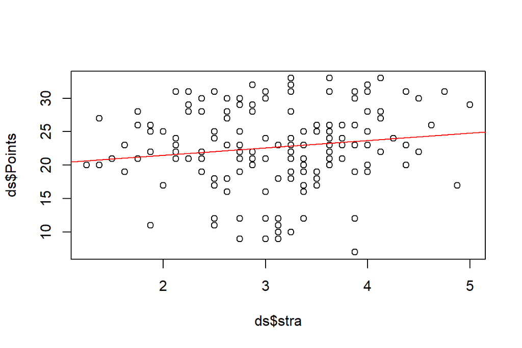

```r
my_model <- lm(Points  ~ stra, data = ds )
plot(ds$stra,ds$Points)
abline(my_model, col="red")
```

```r
my_model
```

```
##
## Call:
## lm(formula = Points ~ stra, data = ds)
##
## Coefficients:
## (Intercept)         stra
##      19.234        1.116
```

```r
summary(my_model)
```

```
##
## Call:
## lm(formula = Points ~ stra, data = ds)
##
## Residuals:
##      Min       1Q   Median       3Q      Max
## -16.5581  -3.8198   0.1042   4.3024  10.1394
##
## Coefficients:
##             Estimate Std. Error t value Pr(>|t|)
## (Intercept)   19.233      1.897  10.141   <2e-16 ***
## stra           1.116      0.590   1.892   0.0603 .
## ---
## Signif. codes:  0 '***' 0.001 '**' 0.01 '*' 0.05 '.' 0.1 ' ' 1
##
## Residual standard error: 5.849 on 164 degrees of freedom
## Multiple R-squared:  0.02135,    Adjusted R-squared:  0.01538
## F-statistic: 3.578 on 1 and 164 DF,  p-value: 0.06031
```

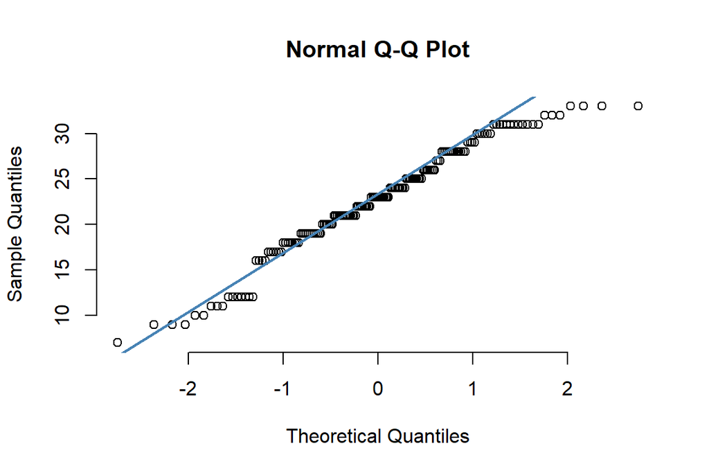

```r
qqnorm(ds$Points, pch = 1, frame = FALSE)
qqline(ds$Points, col = "steelblue", lwd = 2)
```

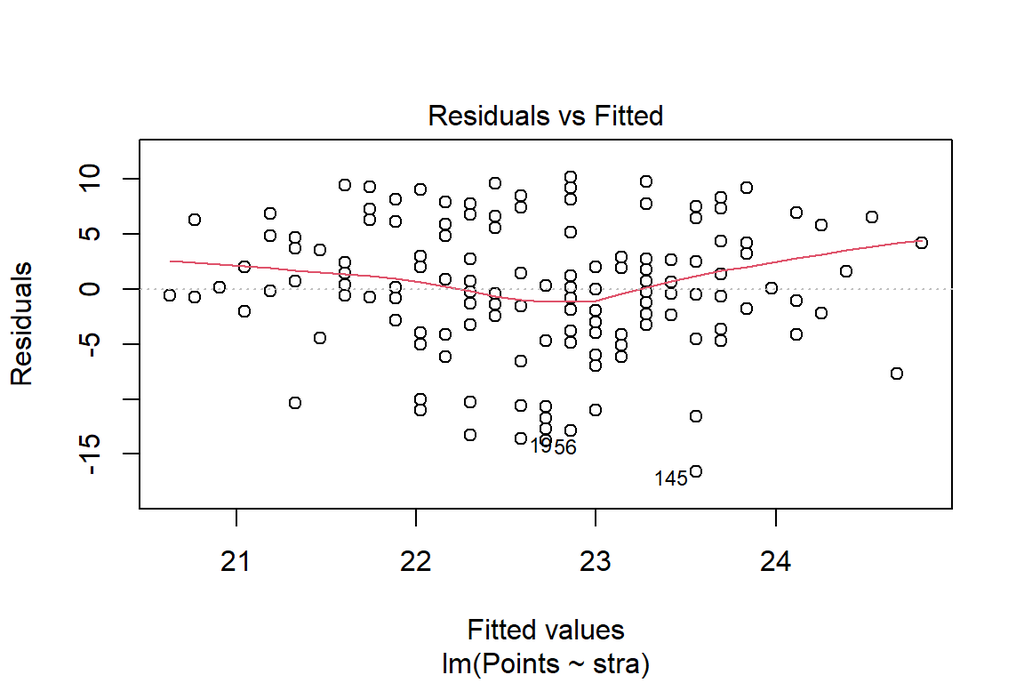

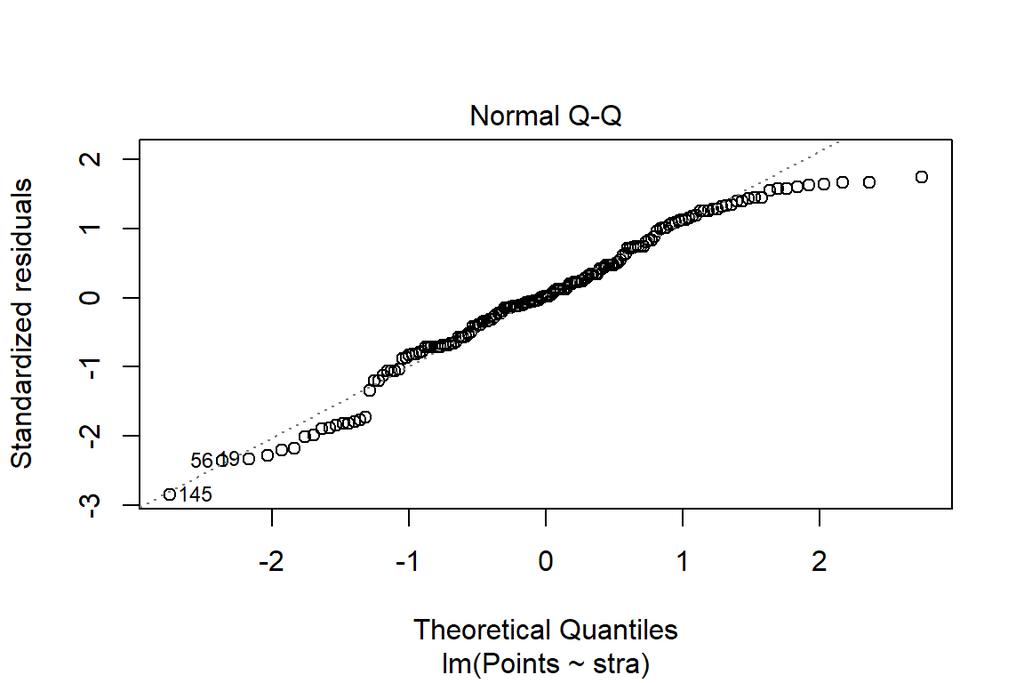

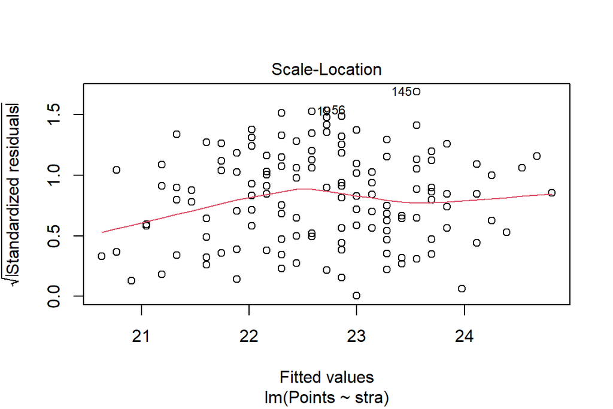

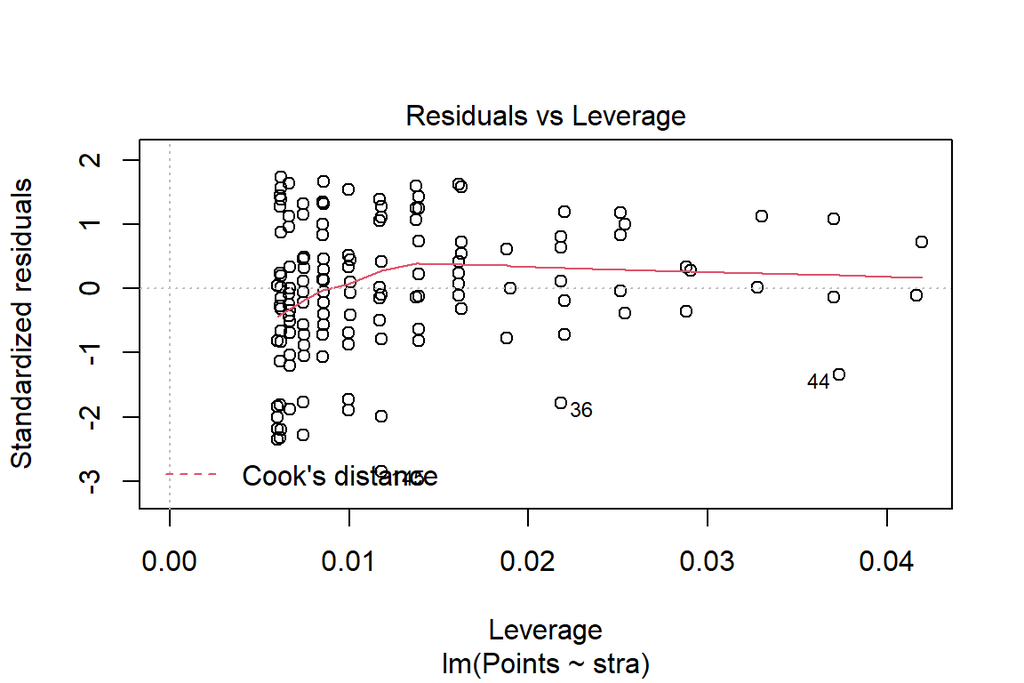

```r
plot(lm(Points~stra,data=ds))
```

The assumption is that the strategic approach (stra) defines the overall points (Points): Points is modelled as a linear combination of stra. Residual is the difference between an observed value of the response variable and the fitted value, the error. Residuals can be used to define the validity of the model assumptions. There are several assumptions for the errors. First of them is that they are normally distributed. QQ-plot of the residuals is a method to explore the assumption that the errors of the model are normally distributed. The better the data points aline with the line the better they are normally distributed. In our example QQ-plot the beginning and end of the line do not follow but in the middle the data point are quite well following the line. We could say the errors are well fitting the line with values -1 and 1.5, reasonably well with values less than -1, not so well fitting with values larger than 1.5. Therefore the errors are reasonable well normally distributed. The second assumption is the constant variance of errors, the size of the errors is not dependent on the explanatory variables. This can be explored with a scatter plot of residuals versus model predictions. Any patter in the scatter plot implies that there is a problem with this assumption. In our example there is no patter to be found and therefore this assumption is correct. Leverage is used to measure how much impact an observation has to the model. Residuals vs leverage plot can be used to find observations that have unusually high impact, the outliers. In our example there are no outliers.

# Logistic regression

```r
date()
```

```
## [1] "Thu Nov 12 10:33:20 2020"
```

```r
alc <- read.csv("C:/Users/Heli/Heli/HY/Introduction to Open Data Science/Projects/IODS-project/data\\alc.csv",sep=",", header=TRUE)

colnames(alc)
```

```
##  [1] "school"     "sex"        "age"        "address"    "famsize"
##  [6] "Pstatus"    "Medu"       "Fedu"       "Mjob"       "Fjob"
## [11] "reason"     "nursery"    "internet"   "guardian"   "traveltime"
## [16] "studytime"  "failures"   "schoolsup"  "famsup"     "paid"
## [21] "activities" "higher"     "romantic"   "famrel"     "freetime"
## [26] "goout"      "Dalc"       "Walc"       "health"     "absences"
## [31] "G1"         "G2"         "G3"         "alc_use"    "high_use"
```

```r
dim(alc)
```

```
## [1] 382  35
```

```r
str(alc)
```

```
## 'data.frame':    382 obs. of  35 variables:
##  $ school    : chr  "GP" "GP" "GP" "GP" ...
##  $ sex       : chr  "F" "F" "F" "F" ...
##  $ age       : int  18 17 15 15 16 16 16 17 15 15 ...
##  $ address   : chr  "U" "U" "U" "U" ...
##  $ famsize   : chr  "GT3" "GT3" "LE3" "GT3" ...
##  $ Pstatus   : chr  "A" "T" "T" "T" ...
##  $ Medu      : int  4 1 1 4 3 4 2 4 3 3 ...
##  $ Fedu      : int  4 1 1 2 3 3 2 4 2 4 ...
##  $ Mjob      : chr  "at_home" "at_home" "at_home" "health" ...
##  $ Fjob      : chr  "teacher" "other" "other" "services" ...
##  $ reason    : chr  "course" "course" "other" "home" ...
##  $ nursery   : chr  "yes" "no" "yes" "yes" ...
##  $ internet  : chr  "no" "yes" "yes" "yes" ...
##  $ guardian  : chr  "mother" "father" "mother" "mother" ...
```

[output cut: 21 more lines]

```r
summary(alc)
```

```
##     school              sex                 age          address
##  Length:382         Length:382         Min.   :15.00   Length:382
##  Class :character   Class :character   1st Qu.:16.00   Class :character
##  Mode  :character   Mode  :character   Median :17.00   Mode  :character
##                                        Mean   :16.59
##                                        3rd Qu.:17.00
##                                        Max.   :22.00
##    famsize            Pstatus               Medu            Fedu
##  Length:382         Length:382         Min.   :0.000   Min.   :0.000
##  Class :character   Class :character   1st Qu.:2.000   1st Qu.:2.000
##  Mode  :character   Mode  :character   Median :3.000   Median :3.000
##                                        Mean   :2.806   Mean   :2.565
##                                        3rd Qu.:4.000   3rd Qu.:4.000
##                                        Max.   :4.000   Max.   :4.000
##      Mjob               Fjob              reason            nursery
##  Length:382         Length:382         Length:382         Length:382
##  Class :character   Class :character   Class :character   Class :character
##  Mode  :character   Mode  :character   Mode  :character   Mode  :character
##
##
##
##    internet           guardian           traveltime      studytime
##  Length:382         Length:382         Min.   :1.000   Min.   :1.000
##  Class :character   Class :character   1st Qu.:1.000   1st Qu.:1.000
##  Mode  :character   Mode  :character   Median :1.000   Median :2.000
##                                        Mean   :1.448   Mean   :2.037
##                                        3rd Qu.:2.000   3rd Qu.:2.000
##                                        Max.   :4.000   Max.   :4.000
##     failures       schoolsup            famsup              paid
##  Min.   :0.0000   Length:382         Length:382         Length:382
##  1st Qu.:0.0000   Class :character   Class :character   Class :character
##  Median :0.0000   Mode  :character   Mode  :character   Mode  :character
##  Mean   :0.2016
##  3rd Qu.:0.0000
##  Max.   :3.0000
##   activities           higher            romantic             famrel
##  Length:382         Length:382         Length:382         Min.   :1.000
##  Class :character   Class :character   Class :character   1st Qu.:4.000
##  Mode  :character   Mode  :character   Mode  :character   Median :4.000
##                                                           Mean   :3.937
```

[output cut: 8 more lines]

```
##  Max.   :5.00   Max.   :5.000   Max.   :5.000   Max.   :5.000   Max.   :5.000
##     absences          G1              G2              G3           alc_use
##  Min.   : 0.0   Min.   : 2.00   Min.   : 4.00   Min.   : 0.00   Min.   :1.000
##  1st Qu.: 1.0   1st Qu.:10.00   1st Qu.:10.00   1st Qu.:10.00   1st Qu.:1.000
##  Median : 3.0   Median :12.00   Median :12.00   Median :12.00   Median :1.500
##  Mean   : 4.5   Mean   :11.49   Mean   :11.47   Mean   :11.46   Mean   :1.889
##  3rd Qu.: 6.0   3rd Qu.:14.00   3rd Qu.:14.00   3rd Qu.:14.00   3rd Qu.:2.500
##  Max.   :45.0   Max.   :18.00   Max.   :18.00   Max.   :18.00   Max.   :5.000
##   high_use
##  Mode :logical
##  FALSE:268
##  TRUE :114
##
##
##
```

My assumption is that going out (goout), and absences (absences) increase the consumption of alcohol whereas the more time spent on studies (studytime) and other activities (activities) the lower the consumption is.

```r
library(tidyr); library(dplyr); library(ggplot2)
glimpse(alc)
```

```
## Rows: 382
## Columns: 35
## $ school     <chr> "GP", "GP", "GP", "GP", "GP", "GP", "GP", "GP", "GP", "G...
## $ sex        <chr> "F", "F", "F", "F", "F", "M", "M", "F", "M", "M", "F", "...
## $ age        <int> 18, 17, 15, 15, 16, 16, 16, 17, 15, 15, 15, 15, 15, 15, ...
## $ address    <chr> "U", "U", "U", "U", "U", "U", "U", "U", "U", "U", "U", "...
## $ famsize    <chr> "GT3", "GT3", "LE3", "GT3", "GT3", "LE3", "LE3", "GT3", ...
## $ Pstatus    <chr> "A", "T", "T", "T", "T", "T", "T", "A", "A", "T", "T", "...
## $ Medu       <int> 4, 1, 1, 4, 3, 4, 2, 4, 3, 3, 4, 2, 4, 4, 2, 4, 4, 3, 3,...
## $ Fedu       <int> 4, 1, 1, 2, 3, 3, 2, 4, 2, 4, 4, 1, 4, 3, 2, 4, 4, 3, 2,...
## $ Mjob       <chr> "at_home", "at_home", "at_home", "health", "other", "ser...
## $ Fjob       <chr> "teacher", "other", "other", "services", "other", "other...
## $ reason     <chr> "course", "course", "other", "home", "home", "reputation...
## $ nursery    <chr> "yes", "no", "yes", "yes", "yes", "yes", "yes", "yes", "...
## $ internet   <chr> "no", "yes", "yes", "yes", "no", "yes", "yes", "no", "ye...
```

[output cut: 22 more lines]

```r
gather(alc) %>% glimpse
```

```
## Rows: 13,370
## Columns: 2
## $ key   <chr> "school", "school", "school", "school", "school", "school", "...
## $ value <chr> "GP", "GP", "GP", "GP", "GP", "GP", "GP", "GP", "GP", "GP", "...
```

```r
g <- gather(alc) %>% ggplot(aes(value)) + facet_wrap("key", scales = "free")
```

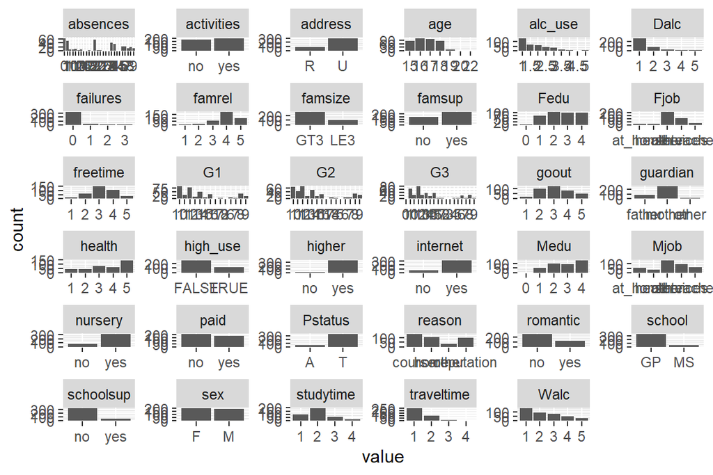

```r
g + geom_bar()
```

Key-value pairs of the data.

```r
my_model <- lm(high_use  ~ goout + absences + studytime + activities, data = alc )
summary(my_model)
```

```
##
## Call:
## lm(formula = high_use ~ goout + absences + studytime + activities,
##     data = alc)
##
## Residuals:
##     Min      1Q  Median      3Q     Max
## -0.8109 -0.3015 -0.1403  0.3580  1.0860
##
## Coefficients:
##                Estimate Std. Error t value Pr(>|t|)
## (Intercept)    0.023625   0.086675   0.273 0.785336
## goout          0.134130   0.019165   6.999 1.19e-11 ***
## absences       0.013991   0.003939   3.552 0.000430 ***
## studytime     -0.088581   0.025683  -3.449 0.000626 ***
## activitiesyes -0.047960   0.042727  -1.122 0.262380
## ---
## Signif. codes:  0 '***' 0.001 '**' 0.01 '*' 0.05 '.' 0.1 ' ' 1
##
## Residual standard error: 0.4146 on 377 degrees of freedom
## Multiple R-squared:  0.1897, Adjusted R-squared:  0.1811
## F-statistic: 22.06 on 4 and 377 DF,  p-value: 2.228e-16
```

The t-value measures the size of the difference relative to the variation, so the bigger the number the greater the evidence against the null hypothesis. Goout, absences, and studytime have t-value great enough to refute the 0-hypotheses. p-value (Pr) is less than 0.05 for all those three. Based on the results, null hypotheses can be refute for goout, absence, and studytime. It cannot be refute for activities. We will build the model without activities. As expected it looks like goout and absences increse the alcohol consumption and studytime degreses it. Activities do not seen to have a clear affect.

```r
my_model2 <- lm(high_use  ~ goout + absences + studytime, data = alc )
summary(my_model2)
```

```
##
## Call:
## lm(formula = high_use ~ goout + absences + studytime, data = alc)
##
## Residuals:
##     Min      1Q  Median      3Q     Max
## -0.7837 -0.2938 -0.1357  0.3622  1.0642
##
## Coefficients:
##              Estimate Std. Error t value Pr(>|t|)
## (Intercept)  0.007067   0.085440   0.083 0.934125
## goout        0.133271   0.019156   6.957 1.54e-11 ***
## absences     0.013966   0.003940   3.545 0.000442 ***
## studytime   -0.091472   0.025563  -3.578 0.000391 ***
## ---
## Signif. codes:  0 '***' 0.001 '**' 0.01 '*' 0.05 '.' 0.1 ' ' 1
##
## Residual standard error: 0.4148 on 378 degrees of freedom
## Multiple R-squared:  0.187,  Adjusted R-squared:  0.1805
## F-statistic: 28.97 on 3 and 378 DF,  p-value: < 2.2e-16
```

alcohol consumption = 0.01 + 0.13 * goout + 0.01 * absences - 0.10 * studytime

Residual Standard Error: Standard deviation of residuals / errors of the regression model. Multiple R-Squared: Percent of the variance of exam intact after subtracting the error of the model. Adjusted R-Squared: how well the model fits the data, i.e. the percentage of the dependent variable variation that the linear model explains (ranging between 0 and 1). The R-squared is quite low so there is probably something in residual plots we should investigate.

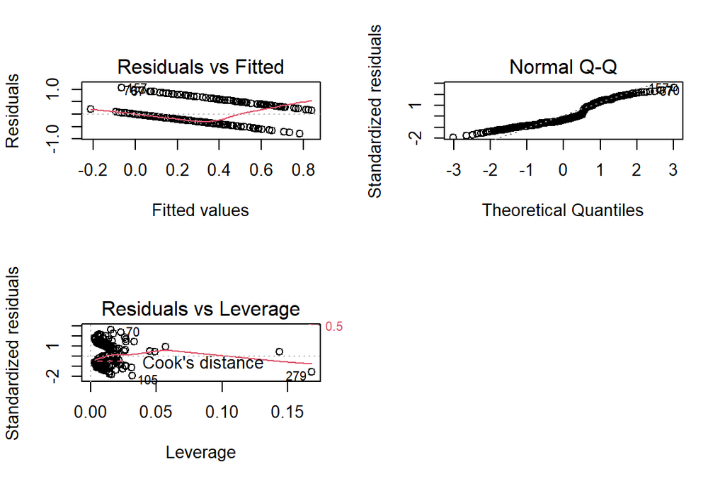

```r
par(mfrow = c(2,2))
plot(my_model2, which=c(1,2,5))
```

The residual vs Fitted shows that the residuals are not at all on the regression line. QQ-plot shows that the datapoints really do not follow the regression line well. Residulas vs leverage plot shows most of the points in the beginning of the line. Most likely the model is not linear. (There are no points outside the Cook’s distance, so no big outliers.)

```r
# grouping the data by goout, absences and studytime. counting the count and the mean of alc_use.
alc %>% group_by(goout, absences, studytime) %>% summarise(count = n(), mean_grade=mean(high_use))
```

```
## # A tibble: 165 x 5
## # Groups:   goout, absences [77]
##    goout absences studytime count mean_grade
##    <int>    <int>     <int> <int>      <dbl>
##  1     1        0         1     4        0
##  2     1        0         2     2        0
##  3     1        1         1     1        0
##  4     1        1         2     3        0
##  5     1        1         4     1        0
##  6     1        2         1     2        0.5
##  7     1        2         2     1        0
##  8     1        3         2     1        0
##  9     1        5         3     1        1
## 10     1        8         1     1        0
## # ... with 155 more rows
```

Those with 0 or 1 as mean_grade are low and high in comsumption but other values have variance. For example if we see a student with go out=5, absences=19, and studytime=2, the data shows high consumption. But a student with the same go out and studytime but even more absence (21) shows low consumptiton. Since there are no outliers this must be a true data point and the regression is not linear.

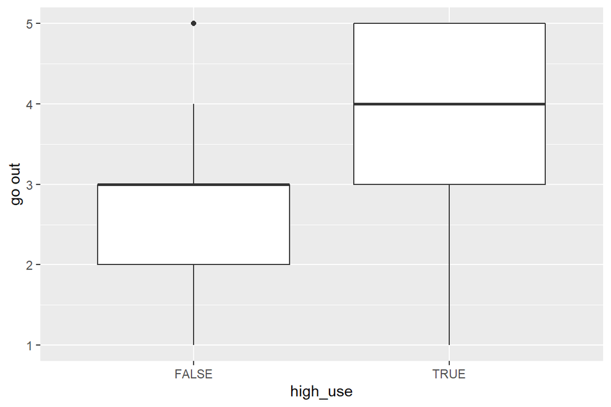

```r
library(ggplot2)
g1 <- ggplot(alc, aes(x = high_use, y = goout))
g1 + geom_boxplot() + ylab("go out")
```

Base on the box plot is shows that high_use and going out a lot have a correlation.

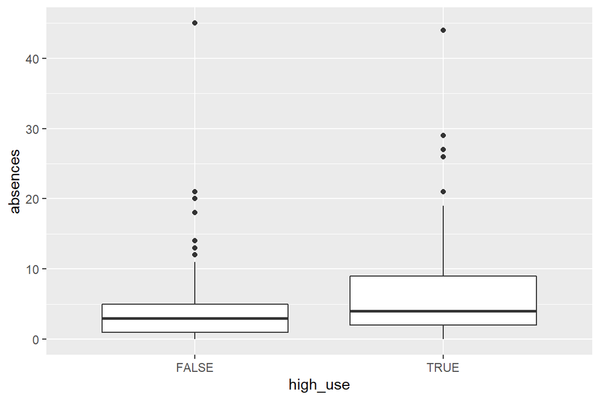

```r
g2 <- ggplot(alc, aes(x = high_use, y = absences))
g2 + geom_boxplot() + ylab("absences")
```

Based on the box plot it loos like more absences means more alcohol consumption. There are some exceptions though.

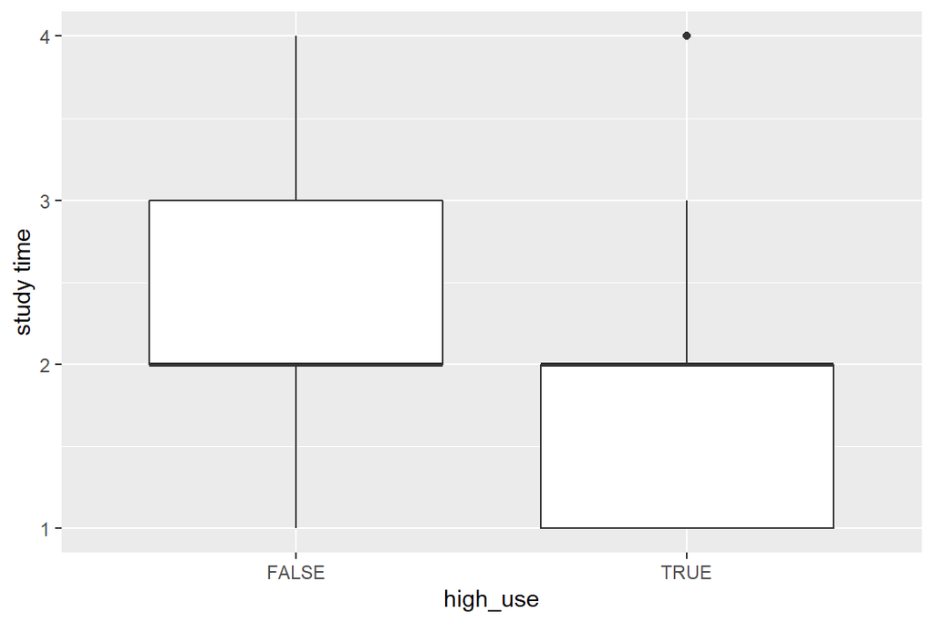

```r
g3 <- ggplot(alc, aes(x = high_use, y = studytime))
g3 + geom_boxplot() + ylab("study time")
```

Base on this box plot the more students spent time on studying the less they consume alcohol. Let’s build a logistic model (my_model3).

```r
my_model3 <- glm(high_use ~ goout + absences + studytime, data = alc, family = "binomial")
summary(my_model3)
```

```
##
## Call:
## glm(formula = high_use ~ goout + absences + studytime, family = "binomial",
##     data = alc)
##
## Deviance Residuals:
##     Min       1Q   Median       3Q      Max
## -1.8457  -0.7733  -0.5178   0.8432   2.5036
##
## Coefficients:
##             Estimate Std. Error z value Pr(>|z|)
## (Intercept) -2.48582    0.52982  -4.692 2.71e-06 ***
## goout        0.72735    0.11786   6.171 6.78e-10 ***
## absences     0.07011    0.02204   3.181 0.001470 **
## studytime   -0.56048    0.16672  -3.362 0.000774 ***
## ---
## Signif. codes:  0 '***' 0.001 '**' 0.01 '*' 0.05 '.' 0.1 ' ' 1
##
## (Dispersion parameter for binomial family taken to be 1)
##
##     Null deviance: 465.68  on 381  degrees of freedom
## Residual deviance: 390.14  on 378  degrees of freedom
## AIC: 398.14
##
## Number of Fisher Scoring iterations: 4
```

Let’s see the coefficients of the model.

```r
coef(my_model3)
```

```
## (Intercept)       goout    absences   studytime
## -2.48582049  0.72734718  0.07011218 -0.56048258
```

goout nad studytime has stronger coeffience on high_use than absences.

```r
# compute odds ratios (OR)
OR <- coef(my_model3) %>% exp
# compute confidence intervals (CI)
CI <- confint(my_model3) %>% exp
# print out the odds ratios with their confidence intervals
cbind(OR, CI)
```

```
##                     OR      2.5 %    97.5 %
## (Intercept) 0.08325721 0.02864231 0.2297441
## goout       2.06958310 1.65203749 2.6250666
## absences    1.07262851 1.02840235 1.1225709
## studytime   0.57093348 0.40733791 0.7846264
```

Odds Ratio is a measure of the strength of association with an exposure and an outcome. OR > 1 means greater odds of association with the exposure and outcome, the X is positively associated with “success” in our case high consumption of alcohol. Goout clearly has great odds, absences not that clear (1.07 > 1) but still has, and studytime (<1) means lower odds of association between the exposure and outcome. Confidence intervals (2.5 and 97.5) shows the confidence of odds ratio.

```r
# predict() the probability of high_use
probabilities <- predict(my_model3, type = "response")
# add the predicted probabilities to 'alc'
alc <- mutate(alc, probability = probabilities)
# use the probabilities to make a prediction of high_use
alc <- mutate(alc, prediction = probability > 0.5)
# see the first ten original classes, predicted probabilities, and class predictions
select(alc, failures, absences, sex, high_use, probability, prediction) %>% head(10)
```

```
##    failures absences sex high_use probability prediction
## 1         0        5   F    FALSE  0.41414989      FALSE
## 2         0        3   F    FALSE  0.22892212      FALSE
## 3         2        8   F     TRUE  0.16921600      FALSE
## 4         0        1   F    FALSE  0.06645515      FALSE
## 5         0        2   F    FALSE  0.11796259      FALSE
## 6         0        8   M    FALSE  0.16921600      FALSE
## 7         0        0   M    FALSE  0.33238962      FALSE
## 8         0        4   F    FALSE  0.39724726      FALSE
## 9         0        0   M    FALSE  0.10413596      FALSE
## 10        0        0   M    FALSE  0.05317940      FALSE
```

This shows the prediction and the probability to that prediction. Prediction is compared to the true value (high_use) to see how good it is.

```r
# create the confusion matrix, tabulate the target variable versus the predictions
table(high_use = alc$high_use, prediction = alc$prediction)
```

```
##         prediction
## high_use FALSE TRUE
##    FALSE   246   22
##    TRUE     66   48
```

The number of correct predictions for false (true negatives) is 246 and the incorrect (false positives) is 22. The number of correct predictions for true (true positives) is 48 and the incorrect (false negatives) is 66. The model can predict students that do not consume high amount of alcohol quite well but it cannot predict those consuming a lot as well.

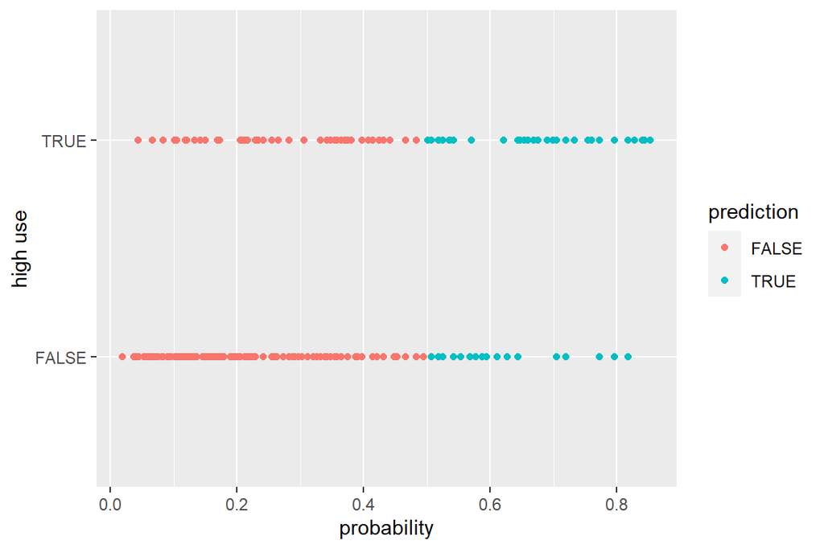

```r
# initialize a plot of 'high_use' versus 'probability' in 'alc'
g11 <- ggplot(alc, aes(x = probability, y = high_use ))

g11 + geom_point(aes(col = prediction)) + ylab("high use")
```

```r
# confusion matrix with probabilities
table(high_use = alc$high_use, prediction = alc$prediction) %>% prop.table() %>% addmargins()
```

```
##         prediction
## high_use      FALSE       TRUE        Sum
##    FALSE 0.64397906 0.05759162 0.70157068
##    TRUE  0.17277487 0.12565445 0.29842932
##    Sum   0.81675393 0.18324607 1.00000000
```

This proves the analyses made earlier: the prediction for false sís much better than the one for true.

```r
# define a loss function (mean prediction error)
loss_func <- function(class, prob) {
  n_wrong <- abs(class - prob) > 0.5
  mean(n_wrong)
}
# call loss_func to compute the average number of wrong predictions in the (training) data
loss_func(class = alc$high_use, prob = 0)
```

```
## [1] 0.2984293
```

The probability for a wrong prediction is about 30%.

```r
loss_func(class = alc$high_use, prob = 1)
```

```
## [1] 0.7015707
```

```r
# probability based on the column probability
loss_func(class = alc$high_use, prob = alc$probability)
```

```
## [1] 0.2303665
```

```r
# 10-fold cross-validation
library(boot)
cv <- cv.glm(data = alc, cost = loss_func, glmfit = my_model3, K = 10)
# average number of wrong predictions in the cross validation
cv$delta[1]
```

```
## [1] 0.2356021
```

The error rate is a little bit better (0.24) than the one in DataCamp (0.26).

```r
# 10-fold cross-validation for different models
# "school","sex","age","address","famsize","Pstatus","Medu","Fedu","Mjob","Fjob","reason","nursery","internet",
# "guardian","traveltime","studytime","failures","schoolsup","famsup","paid","activities","higher","romantic",
# "famrel","freetime","goout","Dalc","Walc","health","absences","G1","G2","G3","alc_use","high_use"
my_model4 <- glm(high_use ~ school + sex + age + Pstatus + Medu + Fedu + Mjob + Fjob + reason + nursery + internet + guardian + traveltime + studytime + failures + schoolsup + famsup + paid + activities + higher + romantic + famrel + freetime + goout + health + absences + G1 + G2+ G3, data = alc, family = "binomial")
cv <- cv.glm(data = alc, cost = loss_func, glmfit = my_model4, K = 10)
# average number of wrong predictions in the cross validation
cv$delta[1]
```

```
## [1] 0.2460733
```

Using a model with many predictors is not useful since the error rate is higher than for the model with less predictors.

```r
my_model5 <- glm(high_use ~ sex + age + internet + guardian + traveltime + studytime + failures + schoolsup + famsup + paid + activities + higher + romantic + famrel + freetime + goout + health + absences + G1 + G2+ G3, data = alc, family = "binomial")
cv <- cv.glm(data = alc, cost = loss_func, glmfit = my_model5, K = 10)
# average number of wrong predictions in the cross validation
cv$delta[1]
```

```
## [1] 0.2356021
```

The error rate gets smaller when reducing the predictors (those that have no correlation to high_usage).

```r
my_model6 <- glm(high_use ~ sex + age + internet + guardian + traveltime + studytime + failures + schoolsup + famsup + activities + higher + romantic + freetime + goout + health + absences + G1 + G2+ G3, data = alc, family = "binomial")
cv <- cv.glm(data = alc, cost = loss_func, glmfit = my_model6, K = 10)
# average number of wrong predictions in the cross validation
cv$delta[1]
```

```
## [1] 0.2277487
```

The error rate gets smaller when reducing the predictors (those that have no correlation to high_usage).

(more chapters to be added similarly as we proceed with the course!)